# Projekt: Analiza porabe električne energije v Pennsylvaniji in v Sloveniji

Ambrož Luin

2022-06-19

## Uvod

Sem študent Računalništva in informatike. Pri predmetu Podatkovno programiranje sem dobil nalogo, da preučim poljubno izbrano podatkovno bazo.

Ker me zanima energetika sem se odločil, da bom najprej preučil podatkovno bazo “Hourly Energy Consumption”, ki sem jo našel na spletni strani: URL: [https://www.kaggle.com/datasets/robikscube/hourly-energy-consumption, 3.5.2022].

Kasneje sem svoj projekt nekoliko razširil in vanj vključil še analizo porabe elektricne energije v Sloveniji. Analizo sem opravil na podoben način. Podatke sem našel na spletni strani statističnega urada Slovenije: SiStat (Republika Slovenija statistični urad). URL: [https://pxweb.stat.si/SiStatData/pxweb/sl/Data/-/1817901S.px, 20.5.2022]

Projekt je obljavljen tudi na spletu https://www.netlify.com/ s pomočjo netify.

## Predstavitev in opis problema

1. Izbrane vhodne podatke je potrebno razumeti. Zato jih je smiselno najprej urediti in jih grafično predstaviti.

Po opravljeni prvi točki lahko pričnemo s podrobejšo analizo podatkov.

Zato, da jih bom še bolje razumel je podatke smiselno grafično predstaviti s pomočjo ggplota. Sedaj lahko pričnem s podrobnejo analizo podatkov.

S pomočjo izbranih zbirk podatkov si lahko postavimo številna vprašanja in poskusimo rešiti zanimiva problemska stanja.

Prav tako si želim naučiti, kako izdelati napovedi o uporabi elektricne energije. Pri tem moram najti ustrezen način za izračun napovedi.

People may use most of their appliances at particular hours of the day, resulting in daily seasonality of power consumption People may use electricity differently on weekdays and weekends, resulting in weekly seasonality, and People may use electricity differently at different times of the year, resulting in yearly seasonality Of course, some more unknown factors may also be present, adding further aspects of seasonality. The ordinary ts() object in R cannot handle multiple seasonalities, so I’m going to use msts() from the forecast package instead.

## Prezentacija podatkov

### Podatkovna zbirka “Hourly Energy Consuption”

Podatkovna zbirka “Hourly Energy Consuption” vsebuje veliko število datotek, ki hranijo podatke o urni porabi energije. Ti podatki prihajajo s spletne strani PJM in so zapisani v megavatih (MW). PJM je regionalna organizacija v Združenih državah Amerike. Je del omrežja Eastern Interconnection, ki upravlja električni prenosni sistem, ki oskrbuje vse ali dele držav Delaware, Illinois, Indiana, Kentucky, Maryland, Michigan, New Jersey, Severna Karolina, Ohio, Pennsylvania, Tennessee, Virginia, West Virginia in okrožje. Kolumbije.

```r
mapa = "DataProject/HourlyEnergyConsumption/"
list.files(path = mapa)
```

```
##  [1] "AEP_hourly.csv"      "COMED_hourly.csv"    "DAYTON_hourly.csv"
##  [4] "DEOK_hourly.csv"     "DOM_hourly.csv"      "DUQ_hourly.csv"
##  [7] "EKPC_hourly.csv"     "est_hourly.paruqet"  "FE_hourly.csv"
## [10] "NI_hourly.csv"       "pjm.JPG"             "pjm_hourly_est.csv"
## [13] "PJM_Load_hourly.csv" "PJM+Evolution.jpg"   "PJME_hourly.csv"
## [16] "PJMW_hourly.csv"
```

Na spodnji sliki so prikazana vsa območja v katerih so zbirali podatke.

[figure not shown]

```r
jj <- readJPEG("DataProject/HourlyEnergyConsumption/pjm.jpg",native=TRUE)
plot(0:1,0:1,type="n",ann=FALSE,axes=FALSE)
rasterImage(jj,0,0,1,1)
```

Odločil sem se, da iz celotne zbirke podatkov izberem samo datoteko, ki hrani podatke o porabi energije za Duquesne Light Company, ki deluje predvsem v Pittsburghu, Pennsylvania.

Sedaj, ko sem se omejil na podatke na območje “Duquesne Light Company”, bi bilo smiselno podatke najprej prebrati in preučiti, katere informacije vključujejo. Izbrani podatki beležijo uporabo elektične energije v Mega Watih v eno urnih intervalih.

Podatke je najprej potrebno nekoliko prilagoditi. Na primer, stolepc “Datetime” je potrebno pretvoriti iz “chr” v “Date” obliko.

```r
df <- read.csv('DataProject/HourlyEnergyConsumption/DUQ_hourly.csv', stringsAsFactors = F)

df$Datetime <- as.POSIXct(df$Datetime, '%Y-%m-%d %H:%M:%S', tz="CET")
gt::gt(head(df,2))
```

| Datetime | DUQ_MW |
| --- | --- |
| 2005-12-31 01:00:00 | 1458 |
| 2005-12-31 02:00:00 | 1377 |

```r
gt::gt(tail(df,2))
```

| Datetime | DUQ_MW |
| --- | --- |
| 2018-01-01 23:00:00 | 1820 |
| 2018-01-02 00:00:00 | 1721 |

Ugotovil sem, da imamo v obravnem podatkovnem okvirju zapise od leta 2005 do leta 2018.

### Podatkovna zbirka iz strani SiStat

Na spletni strani SiStat lahko najdemo zbirko podatkov, ki vsebuje mesečni prikaz proizvodnje enelktrične energije, porabo goriv v elektrarnah in gibanje trdi, tekoč in plinastih goriv v Sloveniji.

- Ključne statistike, ki jih objavljajajo so:
  - količina proizvedene električne energije na generatorju in na pragu,
  - količina uvožene in izvožene električne energije,
  - količina porabljenih goriv v termoelektrarnah,
  - proizvedena količina, uvoz, izvoz in oskrba z gorivi.

Ker me zanima poraba električne energije v Sloveniji, sem iz vseh objavljenih podatkov izbral samo podatke, ki prikazujejo mesečno porabo električne energije.

Omeniti je potrebno, da podatki vključujejo mesečne meritve porabe električne energije v Sloveniji od leta 2017 do leta 2022

```r
ues <- read_excel("DataProject/ElePorabaSlo.xlsx")
# Popravimo imena stolpcev oz. preblikujemo zapis datuma
ues$Datum <- str_replace_all(ues$Datum, 'M', '-')

#ues$Datum <- as.yearmon(ues$Datum)

parse_date_time(ues$Datum, "ym") -> ues$Datum
gt::gt(head(ues, 5))
```

| Datum | ElektricnaUporabaMWh |
| --- | --- |
| 2017-01-01 | 1224.784 |
| 2017-02-01 | 1080.615 |
| 2017-03-01 | 1155.908 |
| 2017-04-01 | 1056.259 |
| 2017-05-01 | 1113.236 |

V zgornji tabeli lahko preberemo prvih 5 zapisov o uporabi električne energije v Sloveniji.

## Analiza podatkov

### Analiza “Duquesne Light Company”

Iz zgornjih tabel lahko razberemo, da so bili podatki beleženi od leta 2005 do leta 2018. V letu 2018 so podatki popolni samo za mesec januar.

Iz izbranega podatkovnega okvirja bom grafično predstavil podatke glede na obdobje od leta 2010 do leta 2017.

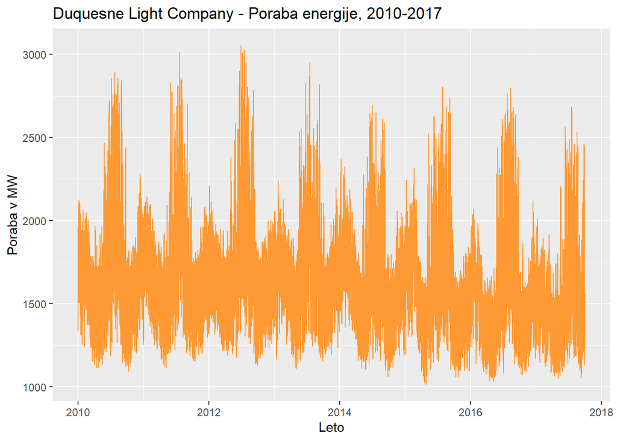

```r
df %>% filter(.$Datetime >= '2010-01-01 00:00:00' & .$Datetime <= '2017-09-30 00:00:00') %>%
  ggplot(., aes(x = Datetime, y = DUQ_MW))+
  geom_line(color = "#FF9933", size = 0.5) +
  ggtitle('Duquesne Light Company - Poraba energije, 2010-2017')+
  xlab('Leto') + ylab('Poraba v MW')
```

Iz grafa lahko razberemo, da se v enakih časovih interavlih pojavljajo podobni vzorci. Na primer, na sredini vsakega leta so viški uporabe električne energije.

Ker bi radi natančneje določili mesec, ko je poraba električne energije visoka. Lahko zgornji graf še nekoliko preuredimo in pogledamo podrobneje za leto 2016.

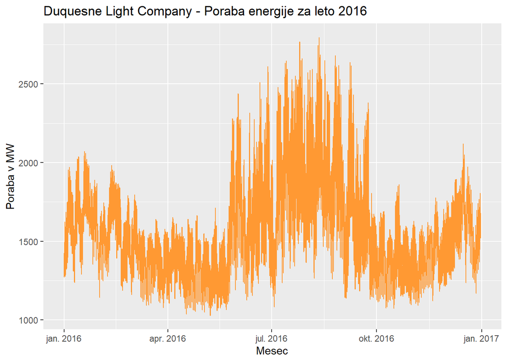

```r
df %>% filter(.$Datetime >= '2016-01-01' & .$Datetime <= '2016-12-31') %>%
  ggplot(., aes(x = Datetime, y = DUQ_MW))+
  geom_line(color = "#FF9933", size = 0.5) +
  ggtitle('Duquesne Light Company - Poraba energije za leto 2016')+
  xlab('Mesec') + ylab('Poraba v MW')
```